# Assignment 3

The zip code that I live in is largely residential. Though technically in San Francisco, my neighborhood primarily consists of single family homes with a few commercial stretches of groceries or other stores. In calculating the GHG emissions for this zip code, I would expect that the majority of emissions are generated from commuters leaving the neighborhood on a daily basis. In my transportation GHG calculation, I also include the trips that commute into the zip code. This is where I start my analysis: I imported Census LODES job data to filter down all the jobs that fit these conditions (i.e. commuting in or out of my zip code, 94127). I looked at home and work geocodes and did not include any pairs where both job and home were in 94127. The reasoning being that these trips contributed a negligible amount of Vehicle Miles Traveled (VMTs) and complicated the analysis.

I generated trip geometries from the MapboxAPI and plotted all commute times here:

[interactive chart not shown]

Initially this map included trips across the entire state; this is likely due to residents in this zip code having business registered in other parts of the state. Had my I included zips nationwide, I would expect to have trips coming from across the country. To control for these outlier trips (which would significantly skew the total VMTs), I am only considering trip times under 2 hours. This is roughly four times the mean commute time in the bay area commute as reported by [CBS SF Bay Area](https://sanfrancisco.cbslocal.com/2020/05/06/coronavirus-covid-19-era-commute-times-could-double-if-bay-area-workers-ditch-transit-for-cars/)

In my actual totaling of VMTs, I throw out the most extreme trips entirely. What I classify as “long commutes” (those > 100 minutes one way), I assume visits happen less frequently than those under 100 minutes. I calculate those trip totals by multiplying the trip miles by 261 days for an annual count. For the trips that they are not happening daily, I assume that they happen half as frequently. In the future, this could be estimated more robustly by using NHTS median commute time data. Using standard deviations might be a less arbitrary way to assign trip counts, but these numbers are reasonable enough for the purpose of this analysis.

Since there are different emission rates associated with different vehicles, I have to consider the types of vehicles and fuels used in trips for different years. To incorporate this, I use annual EMFAC data to weight emissions associated with the VMTs in aggregate each year.

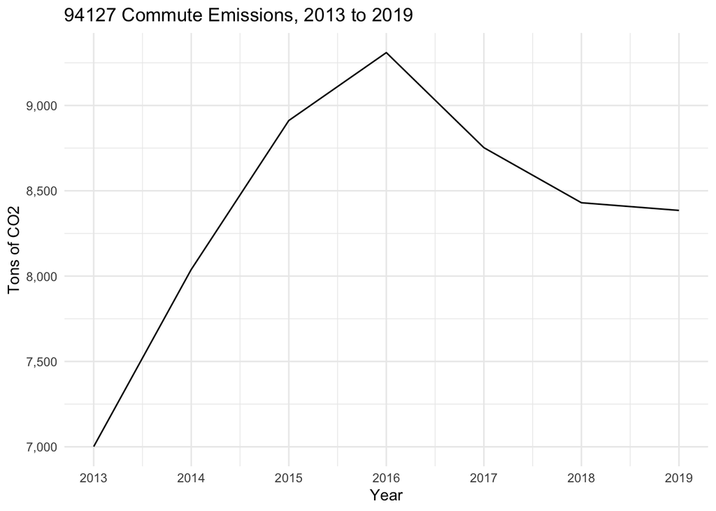

This plot gives some indication that commute emissions associated with the 94127 zip code have started to decrease over the last 3 years. This could be a result of changes in fuel types for these trips. Electric cars, for instance, do not have any associated emissions in this data set; the 94127 zip code likely has a high adoption rate of EVs.

## Building Emissions

Useful to this analysis of GHGs from 94127 is to consider the emissions from buildings as well. Since 2013, PG&E publishes an estimated conversion factor from kWh to tons of CO2e. Using these factors and the reported kBTU and kWh used in 94127, I can total emissions from different building types (commercial and residential), and energy usage (gas and electric). One point to call out is that the factor for 2019 that PG&E reports is two orders of magnitude smaller than the previous years. This is to do with a change in how they are required to report emissions with Community Choice Aggregators and is why there is such a sharp decline in emissions from electricity in 2019.

In the following graph, I plotted the commute emissions with building emissions from each year.

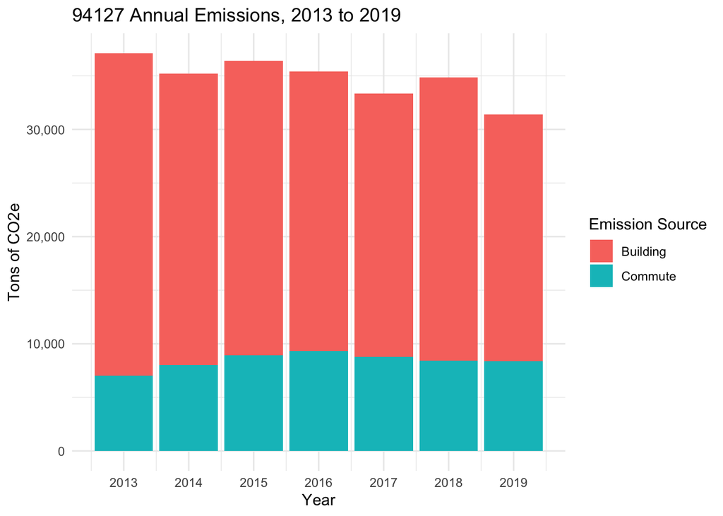

It is somewhat difficult to see much change in the building emissions year to year. The following plot zooms in on what types of energy use is contributing most to CO2e building emissions. Clear here is that gas usage is a much bigger emitter than electricity, which has contributed progressively less CO2e. The near 0 tons of CO2e reported in 2019 is result of the above mentioned change in reporting. Nonetheless, in the years prior, electricity has consistently been contributing less CO2e.

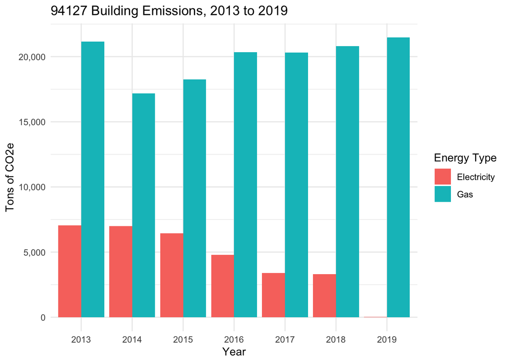

The trend in electricity emissions is promising, especially when considering that there has been little change in the proportion of energy usage between gas and electricity. This is to say that the decrease in emissions from electricity is not associated with a decrease in electricty usage, as clearly seen in the plot below.

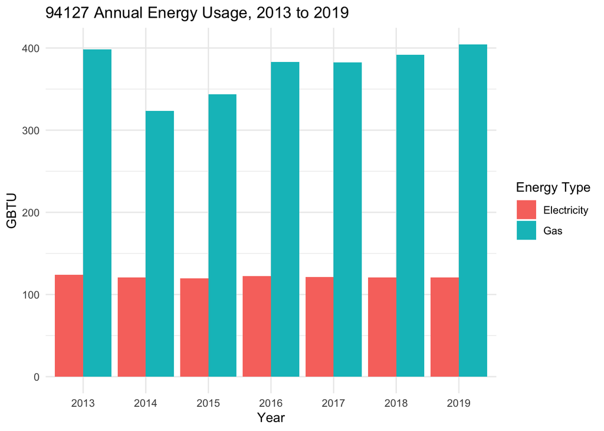

A deeper investigation into building type can reveal other interesting findings. Since 94127 is a largely residential neighborhood, it is reasonable to expect that residential buildings would contribute more to the ultimate GHG totals. A plot of the type of energy by the type of buildings shows that residential gas is far and away the largest contributor of GHGs in the zipcode.

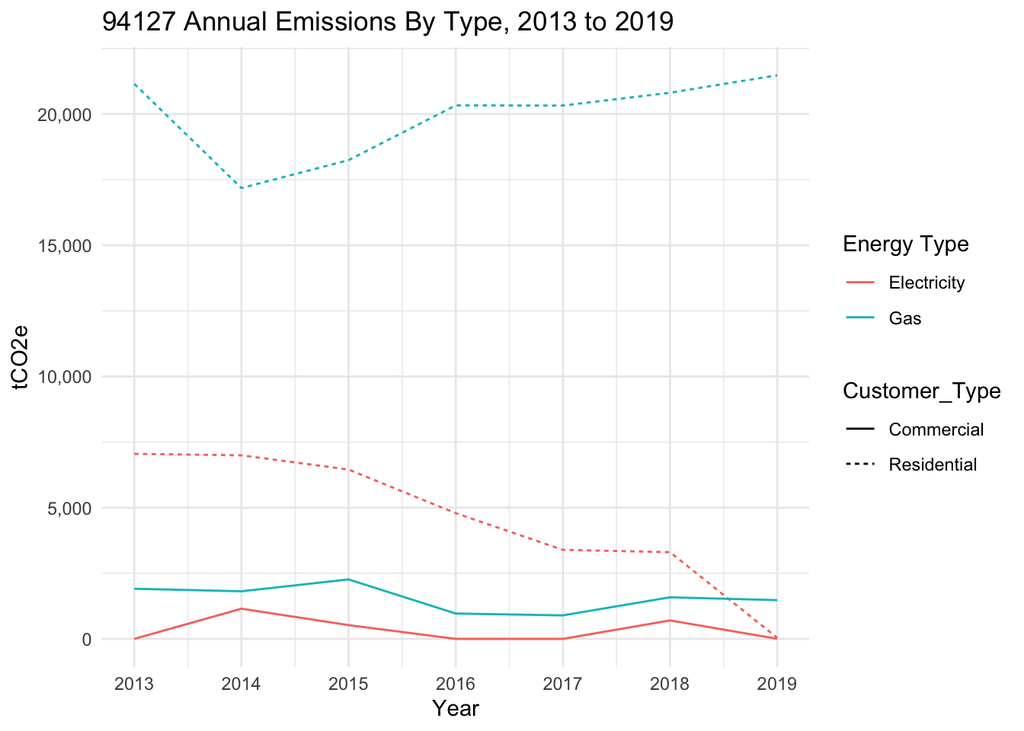

Within this zip code, electrifying homes would appear to have an enormous effect on the overall associate emissions. As there are not many commercial properties, neither the commercial gas or electricity emissions are proportionately very high.

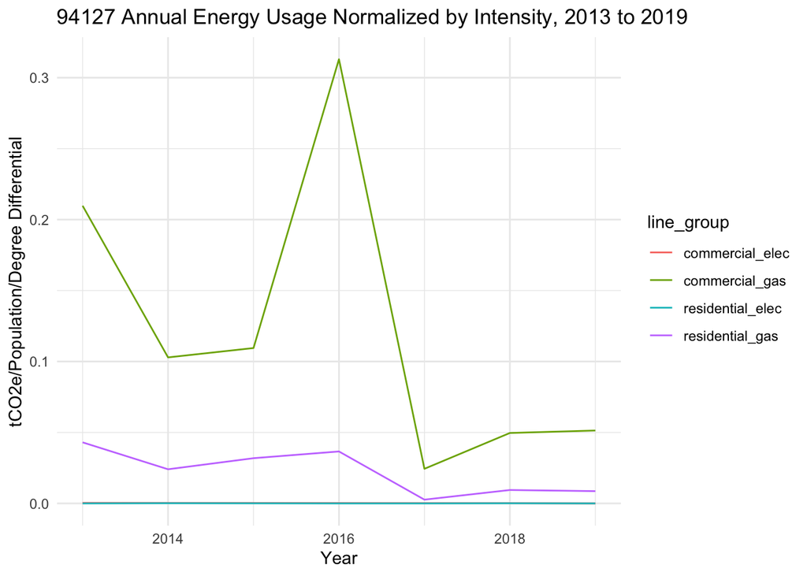